# RNA-Seq: quantification and DE analysis

Laura Toribio-Celestino

May 2023

### Loading required packages

```r
library(Rsubread)
library(DESeq2)
library(apeglm)
library(dplyr)
library(ggplot2)
library(pheatmap)
library(RColorBrewer)
library(EnhancedVolcano)
```

# Quantification with featureCounts

Let’s start by reading the sorted BAM files and the annotation SAF file located in this directory.

```r
bamfiles <- dir(".", ".bam$")
saffile <- dir(".", "saf$")
```

Next, gene-level quantification is performed using featureCounts, which is faster than other methods and requires less computer memory. Strandness was checked before running.

```r
fc <- featureCounts(bamfiles, annot.ext=saffile, strandSpecific=2, isPairedEnd=TRUE, nthreads=15)
```

[output not shown]

[output cut: 30 more lines]

```
## ||    Total alignments : 14497875                                             ||
## ||    Successfully assigned alignments : 13844577 (95.5%)                     ||
## ||    Running time : 1.30 minutes                                             ||
## ||                                                                            ||
## || Process BAM file H53c1.3.bam...                                            ||
## ||    Strand specific : reversely stranded                                    ||
## ||    Paired-end reads are included.                                          ||
## ||    Total alignments : 13165009                                             ||
## ||    Successfully assigned alignments : 12542573 (95.3%)                     ||
## ||    Running time : 1.67 minutes                                             ||
## ||                                                                            ||
## || Write the final count table.                                               ||
## || Write the read assignment summary.                                         ||
## ||                                                                            ||
## \\============================================================================//
```

Count data is exported to a TSV file. Here we’ll see some stats of the count data.

```r
write.table(x=data.frame(fc$annotation[,c("GeneID","Chr", "Length")], fc$counts, stringsAsFactors=FALSE), file="featureCounts.tsv", quote=FALSE, sep="\t", row.names=FALSE)
head(fc$counts)
```

```
##                    H53.1.bam H53.2.bam H53.3.bam H53c1.1.bam H53c1.2.bam
## cds-pgaptmp_000001      3710      3284      2117        1987        2491
## cds-pgaptmp_000002      3053      2356      1936        1642        1938
## cds-pgaptmp_000003       802       821       502         421         647
## cds-pgaptmp_000004      7905      6937      7133        6130        6447
## cds-pgaptmp_000005      2260      2359      2410        2275        2610
## cds-pgaptmp_000006        42        91        44          59          61
##                    H53c1.3.bam
## cds-pgaptmp_000001        1664
## cds-pgaptmp_000002        1329
## cds-pgaptmp_000003         365
## cds-pgaptmp_000004        4910
## cds-pgaptmp_000005        1949
## cds-pgaptmp_000006          23
```

```r
summary(fc$counts)
```

```
##    H53.1.bam        H53.2.bam         H53.3.bam        H53c1.1.bam
##  Min.   :     0   Min.   :      0   Min.   :      0   Min.   :      0
##  1st Qu.:    53   1st Qu.:     69   1st Qu.:     62   1st Qu.:     49
##  Median :   306   Median :    359   Median :    334   Median :    287
##  Mean   :  2564   Mean   :   2399   Mean   :   2636   Mean   :   2435
##  3rd Qu.:  1330   3rd Qu.:   1387   3rd Qu.:   1322   3rd Qu.:   1190
##  Max.   :915688   Max.   :1475525   Max.   :1920494   Max.   :1679502
##   H53c1.2.bam       H53c1.3.bam
##  Min.   :      0   Min.   :      0
##  1st Qu.:     56   1st Qu.:     39
##  Median :    339   Median :    231
##  Mean   :   2559   Mean   :   2318
##  3rd Qu.:   1304   3rd Qu.:   1028
##  Max.   :2014332   Max.   :1186608
```

```r
fc$stat
```

```
##                           Status H53.1.bam H53.2.bam H53.3.bam H53c1.1.bam
## 1                       Assigned  13872332  12978900  14265206    13175708
## 2            Unassigned_Unmapped      5653     10767     10082        9076
## 3           Unassigned_Read_Type         0         0         0           0
## 4           Unassigned_Singleton         0         0         0           0
## 5      Unassigned_MappingQuality         0         0         0           0
## 6             Unassigned_Chimera         0         0         0           0
## 7      Unassigned_FragmentLength         0         0         0           0
## 8           Unassigned_Duplicate         0         0         0           0
## 9        Unassigned_MultiMapping         0         0         0           0
## 10          Unassigned_Secondary         0         0         0           0
## 11           Unassigned_NonSplit         0         0         0           0
## 12         Unassigned_NoFeatures    231958    277630    279631      197507
## 13 Unassigned_Overlapping_Length         0         0         0           0
## 14          Unassigned_Ambiguity    674110    529063    444654      456312
##    H53c1.2.bam H53c1.3.bam
## 1     13844577    12542573
## 2        12160       14225
## 3            0           0
## 4            0           0
## 5            0           0
## 6            0           0
## 7            0           0
## 8            0           0
## 9            0           0
## 10           0           0
## 11           0           0
## 12      223025      140775
## 13           0           0
## 14      418113      467436
```

The count matrices are prepared for the construction of the DESeqDataSet object. Gene IDs are set as row names.

```r
countdata <- fc$counts
colnames(countdata) <- gsub("\\.bam$", "", colnames(countdata))
nrow(countdata)
```

```
## [1] 5411
```

Plotting the total read counts of each sample.

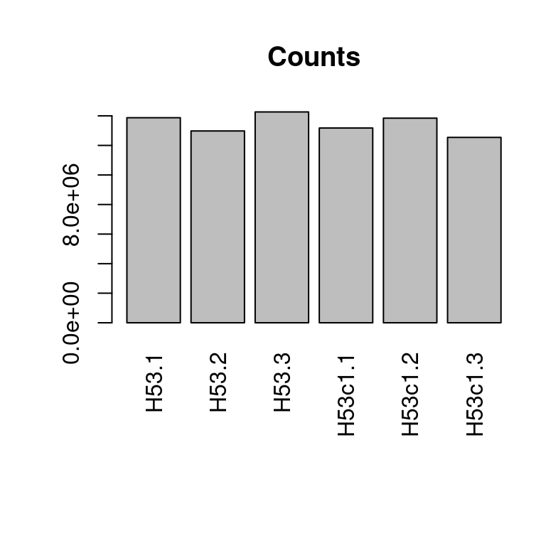

```r
par(mar=c(8,4,4,1)+0.1)
barplot(colSums(countdata), las=3, main="Counts")
```

# DESeqDataSet object and experimental design

Building the variables for the columns of the colData object. The condition of all samples and replicates is specified.

```r
condition <- c('wt', 'wt', 'wt', 'cur', 'cur', 'cur')
replicate <- c('1', '2', '3', '1', '2', '3')
coldata <- as.data.frame(cbind(colnames(countdata), condition, replicate))
coldata
```

```
##        V1 condition replicate
## 1   H53.1        wt         1
## 2   H53.2        wt         2
## 3   H53.3        wt         3
## 4 H53c1.1       cur         1
## 5 H53c1.2       cur         2
## 6 H53c1.3       cur         3
```

Constructing the DESeqDataSet object.

```r
dds <- DESeqDataSetFromMatrix(countData = countdata, colData = coldata, design = ~ condition)
head(dds)
```

```
## class: DESeqDataSet
## dim: 6 6
## metadata(1): version
## assays(1): counts
## rownames(6): cds-pgaptmp_000001 cds-pgaptmp_000002 ...
##   cds-pgaptmp_000005 cds-pgaptmp_000006
## rowData names(0):
## colnames(6): H53.1 H53.2 ... H53c1.2 H53c1.3
## colData names(3): V1 condition replicate
```

```r
nrow(dds)
```

```
## [1] 5411
```

The reference level of the condition’s factors must be specified. The reference will be defined as the pOXA-48-free version of the strain.

```r
dds$condition <- relevel(dds$condition, ref = "cur")
```

## Pre-filtering the dataset

Rows with 0 counts will be removed to increase the speed of the DESeq2 pipeline. Additional weighting/filtering to improve power is applied at a later step in the DESeq2 workflow.

```r
keep <- rowSums(counts(dds)) > 1
dds <- dds[keep,]
nrow(dds)
```

```
## [1] 5377
```

# Analysis of count data

Before exploratory analyses, count data is transformed to stabilize the variance across the mean. The rlog transformation is applied since it works best on small datasets (n<30), in comparison with the VST method.

```r
rld <- rlog(dds, blind = FALSE)
head(assay(rld))
```

```
##                        H53.1     H53.2     H53.3   H53c1.1   H53c1.2   H53c1.3
## cds-pgaptmp_000001 11.622070 11.384848 11.084127 11.123730 11.204020 11.109732
## cds-pgaptmp_000002 11.330072 10.973187 10.879470 10.834427 10.863910 10.792106
## cds-pgaptmp_000003  9.444477  9.339208  8.997595  8.945580  9.191777  8.960141
## cds-pgaptmp_000004 12.834023 12.596329 12.694198 12.659284 12.590899 12.606795
## cds-pgaptmp_000005 11.148807 11.064048 11.155145 11.200961 11.206863 11.205982
## cds-pgaptmp_000006  5.531432  5.966510  5.524575  5.790896  5.724303  5.321261
```

### Heatmap of distances between samples

To observe the similarities and dissimilarities between samples, we plot a heatmap of Euclidean distances. Replicates from each condition should cluster together.

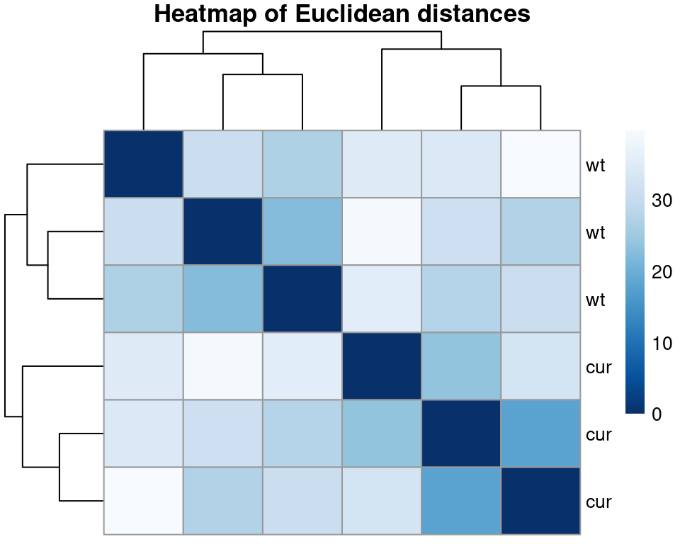

```r
sampleDists <- dist(t(assay(rld)))
sampleDistMatrix <- as.matrix(sampleDists)
rownames(sampleDistMatrix) <- paste(rld$condition, sep="-")
colnames(sampleDistMatrix) <- NULL
colors <- colorRampPalette(rev(brewer.pal(9, "Blues")))(255)
pheatmap(sampleDistMatrix,
         clustering_distance_rows=sampleDists,
         clustering_distance_cols=sampleDists,
         col=colors,
         main="Heatmap of Euclidean distances")
```

### PCA plot

In PCA plots, samples are projected onto the 2D plane such that they spread out in the two directions that explain most of the differences betweem them. The x-axis (PC1) is the direction that separates the data points the most. The y-axis (PC2) is the direction that separates the data the second most. The percent of the total variance that is contained in the direction is printed in the axis label. Replicates from each condition should cluster together.

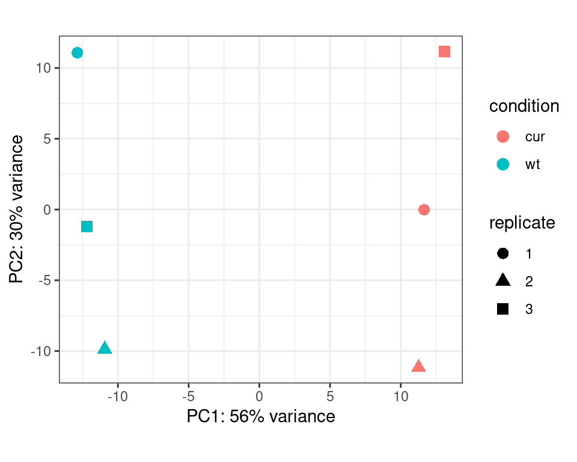

```r
pcaData <- plotPCA(rld, intgroup = c("condition", "replicate"), returnData = TRUE)
percentVar <- round(100 * attr(pcaData, "percentVar"))
ggplot(pcaData, aes(x = PC1, y = PC2, color = condition, shape = replicate)) +
  geom_point(size =3) +
  xlab(paste0("PC1: ", percentVar[1], "% variance")) +
  ylab(paste0("PC2: ", percentVar[2], "% variance")) +
  coord_fixed() +
  theme_bw()
```

## Differential expression analysis

As we have already specified an experimental design when we created the DESeqDataSet, we can run the differential expression pipeline on the raw counts:

```r
dds <- DESeq(dds)
resultsNames(dds)
```

```
## [1] "Intercept"           "condition_wt_vs_cur"
```

We’ll have a look at the summary of the unfiltered DE results. The LFC is shrunken with the apeglm method for visualizing results and ranking the genes for GSEA analysis.

```r
res <- results(dds)
res <- lfcShrink(dds, coef="condition_wt_vs_cur", type="apeglm")
```

```
## using 'apeglm' for LFC shrinkage. If used in published research, please cite:
##     Zhu, A., Ibrahim, J.G., Love, M.I. (2018) Heavy-tailed prior distributions for
##     sequence count data: removing the noise and preserving large differences.
##     Bioinformatics. https://doi.org/10.1093/bioinformatics/bty895
```

```r
res
```

```
## log2 fold change (MAP): condition wt vs cur
## Wald test p-value: condition wt vs cur
## DataFrame with 5377 rows and 5 columns
##                     baseMean log2FoldChange     lfcSE      pvalue        padj
##                    <numeric>      <numeric> <numeric>   <numeric>   <numeric>
## cds-pgaptmp_000001  2497.936     0.00771906 0.0412701    0.167829    0.998816
## cds-pgaptmp_000002  2011.783     0.00902753 0.0416250    0.129615    0.998816
## cds-pgaptmp_000003   579.267     0.00743407 0.0412104    0.172735    0.998816
## cds-pgaptmp_000004  6515.161     0.00587474 0.0404668    0.464354    0.998816
## cds-pgaptmp_000005  2297.218    -0.00637837 0.0403439    0.462163    0.998816
## ...                      ...            ...       ...         ...         ...
## cds-pgaptmp_005433   78.6665       10.59522   2.92104 8.26794e-15 7.93722e-13
## cds-pgaptmp_005434  477.5089       10.17355   1.02872 4.85539e-22 1.30513e-19
## cds-pgaptmp_005435  112.1164       11.18366   2.98063 2.64673e-16 2.96434e-14
## cds-pgaptmp_005436  384.1229       13.18448   3.16110 3.15256e-22 8.92009e-20
## cds-pgaptmp_005355   46.9216        9.73495   2.82839 6.64178e-13 5.57910e-11
```

```r
summary(res)
```

```
##
## out of 5377 with nonzero total read count
## adjusted p-value < 0.1
## LFC > 0 (up)       : 86, 1.6%
## LFC < 0 (down)     : 6, 0.11%
## outliers [1]       : 1, 0.019%
## low counts [2]     : 0, 0%
## (mean count < 0)
## [1] see 'cooksCutoff' argument of ?results
## [2] see 'independentFiltering' argument of ?results
```

The unfiltered DE results are exported to a TSV file (contains NAs and non-significant DEGs).

```r
## The saf file, which contains the RefSeq IDs is read
saftable <- read.csv(saffile, header=TRUE, sep="\t")
saftable <- as.data.frame(saftable)
## Merge with normalized count data and annotation
resdata <- merge(as.data.frame(res), as.data.frame(counts(dds, normalized=TRUE)), by="row.names", sort=FALSE)
names(resdata)[1] <- "GeneID"
resdata <- merge(x=as.data.frame(resdata), saftable, by="GeneID")
head(resdata)
```

```
##               GeneID   baseMean log2FoldChange      lfcSE    pvalue      padj
## 1 cds-pgaptmp_000001 2497.93572    0.007719062 0.04127008 0.1678291 0.9988162
## 2 cds-pgaptmp_000002 2011.78347    0.009027534 0.04162501 0.1296150 0.9988162
## 3 cds-pgaptmp_000003  579.26716    0.007434069 0.04121039 0.1727349 0.9988162
## 4 cds-pgaptmp_000004 6515.16130    0.005874743 0.04046677 0.4643544 0.9988162
## 5 cds-pgaptmp_000005 2297.21784   -0.006378367 0.04034393 0.4621628 0.9988162
## 6 cds-pgaptmp_000006   51.49821    0.001097243 0.04042395 0.7591095 0.9988162
##        H53.1      H53.2      H53.3    H53c1.1    H53c1.2   H53c1.3 Chr Start
## 1 3701.00076 2838.99345 1995.17815 2092.58355 2302.32982 2057.5286   1     1
## 2 3045.59442 2036.74439 1824.59372 1729.25123 1791.21444 1643.3026   1  1409
## 3  800.05461  709.74836  473.11263  443.37075  597.99574  451.3209   1  2717
## 4 7885.82506 5996.98465 6722.53460 6455.73085 5958.69945 6071.1932   1  3819
## 5 2254.51798 2039.33787 2271.31759 2395.88706 2412.31667 2409.9299   1  6435
## 6   41.89812   78.66882   41.46804   62.13509   56.37981   28.4394   1  7397
##    End Strand Type         RefSeq Gene
## 1 1404      +  CDS YP_005229578.1 dnaA
## 2 2509      +  CDS WP_006177590.1 dnaN
## 3 3790      +  CDS WP_005121479.1 recF
## 4 6233      +  CDS WP_005121480.1 gyrB
## 5 7247      +  CDS YP_005229574.1 yidA
## 6 8479      +  CDS YP_005229573.1    -
##                                          Product
## 1 chromosomal replication initiator protein DnaA
## 2                DNA polymerase III subunit beta
## 3            DNA replication/repair protein RecF
## 4  DNA topoisomerase (ATP-hydrolyzing) subunit B
## 5                              sugar-phosphatase
## 6                           hypothetical protein
```

```r
## Write results
write.table(resdata, file="DE_results_raw.tsv", sep="\t", row.names=FALSE)
```

Lowering the FDR threshold on padj (Benjamini-Hochberg adjusted p-values).

```r
resfilt <- results(dds, alpha = 0.05)
table(resfilt$padj < 0.05)
```

```
##
## FALSE  TRUE
##  5291    85
```

```r
resfilt
```

```
## log2 fold change (MLE): condition wt vs cur
## Wald test p-value: condition wt vs cur
## DataFrame with 5377 rows and 6 columns
##                     baseMean log2FoldChange     lfcSE      stat      pvalue
##                    <numeric>      <numeric> <numeric> <numeric>   <numeric>
## cds-pgaptmp_000001  2497.936       0.403468  0.292535  1.379213    0.167829
## cds-pgaptmp_000002  2011.783       0.419451  0.276752  1.515622    0.129615
## cds-pgaptmp_000003   579.267       0.409008  0.299976  1.363469    0.172735
## cds-pgaptmp_000004  6515.161       0.156580  0.213997  0.731696    0.464354
## cds-pgaptmp_000005  2297.218      -0.136854  0.186123 -0.735290    0.462163
## ...                      ...            ...       ...       ...         ...
## cds-pgaptmp_005433   78.6665        9.65016   1.24303   7.76340 8.26794e-15
## cds-pgaptmp_005434  477.5089       10.39064   1.07661   9.65126 4.85539e-22
## cds-pgaptmp_005435  112.1164       10.16177   1.24099   8.18842 2.64673e-16
## cds-pgaptmp_005436  384.1229       11.93912   1.23142   9.69545 3.15256e-22
## cds-pgaptmp_005355   46.9216        8.90695   1.23938   7.18661 6.64178e-13
##                           padj
##                      <numeric>
## cds-pgaptmp_000001    0.998816
## cds-pgaptmp_000002    0.998816
## cds-pgaptmp_000003    0.998816
## cds-pgaptmp_000004    0.998816
## cds-pgaptmp_000005    0.998816
## ...                        ...
## cds-pgaptmp_005433 7.93722e-13
## cds-pgaptmp_005434 1.30513e-19
## cds-pgaptmp_005435 2.96434e-14
## cds-pgaptmp_005436 8.92009e-20
## cds-pgaptmp_005355 5.57910e-11
```

```r
summary(resfilt)
```

```
##
## out of 5377 with nonzero total read count
## adjusted p-value < 0.05
## LFC > 0 (up)       : 83, 1.5%
## LFC < 0 (down)     : 2, 0.037%
## outliers [1]       : 1, 0.019%
## low counts [2]     : 0, 0%
## (mean count < 0)
## [1] see 'cooksCutoff' argument of ?results
## [2] see 'independentFiltering' argument of ?results
```

```r
## Creating a results data frame filtered by padj and LFC
resFilt <- subset(resfilt, padj < 0.05)
## Merge with normalized count data and annotation
resdatafilt <- merge(as.data.frame(resFilt), as.data.frame(counts(dds, normalized=TRUE)), by="row.names", sort=FALSE)
names(resdatafilt)[1] <- "GeneID"
resdatafilt <- merge(x=as.data.frame(resdatafilt), saftable, by="GeneID")
head(resdatafilt)
```

```
##               GeneID    baseMean log2FoldChange     lfcSE       stat
## 1 cds-pgaptmp_001280   872.09953     -0.8120759 0.2208245  -3.677473
## 2 cds-pgaptmp_003274   354.29340     -2.4431935 0.2294333 -10.648817
## 3 cds-pgaptmp_003275  4520.77932      5.8980864 0.3247798  18.160261
## 4 cds-pgaptmp_003276 13958.95156      5.5848236 0.2845112  19.629539
## 5 cds-pgaptmp_003368    68.70741      1.7735926 0.3107071   5.708247
## 6 cds-pgaptmp_005355    46.92160      8.9069550 1.2393813   7.186614
##         pvalue         padj       H53.1      H53.2      H53.3    H53c1.1
## 1 2.355562e-04 1.525723e-02   652.41361   565.3781   681.3953 1006.79913
## 2 1.765945e-26 1.186715e-23   113.72347   105.4681   111.2097  592.91623
## 3 1.065175e-73 2.863191e-70  7462.85355  8246.3942 10969.2388  128.48273
## 4 8.649535e-86 4.649990e-82 20554.02145 26873.6146 34617.3305  586.59740
## 5 1.141459e-08 8.406144e-07   104.74530   108.0616   106.4975   33.70039
## 6 6.641782e-13 5.579097e-11    67.83505   107.1971   106.4975    0.00000
##      H53c1.2    H53c1.3 Chr   Start     End Strand Type         RefSeq Gene
## 1 1242.20444 1084.40661   1 1276333 1277523      -  CDS YP_005228248.1 hmpA
## 2  657.14833  545.29454   1 3272526 3273431      -  CDS YP_005226231.1    -
## 3  205.18556  112.52110   1 3273546 3274406      +  CDS YP_005226230.1    -
## 4  634.96611  487.17925   1 3274425 3275102      +  CDS YP_005226229.1    -
## 5   33.27333   25.96641   1 3383201 3383898      -  CDS WP_076612230.1    -
## 6    0.00000    0.00000   3   63578   64645      +  CDS WP_020316718.1    -
##                                 Product
## 1         NO-inducible flavohemoprotein
## 2 LysR family transcriptional regulator
## 3                  pirin family protein
## 4        isochorismatase family protein
## 5                IS1 family transposase
## 6              replication protein RepA
```

```r
## Order by log2FC
resdatafilt <- resdatafilt[order(resdatafilt$log2FoldChange, decreasing = TRUE), ]
## Write results
write.table(resdatafilt, file="DE_results_filtered_padj.tsv", sep="\t", row.names=FALSE)
```

### MA plot

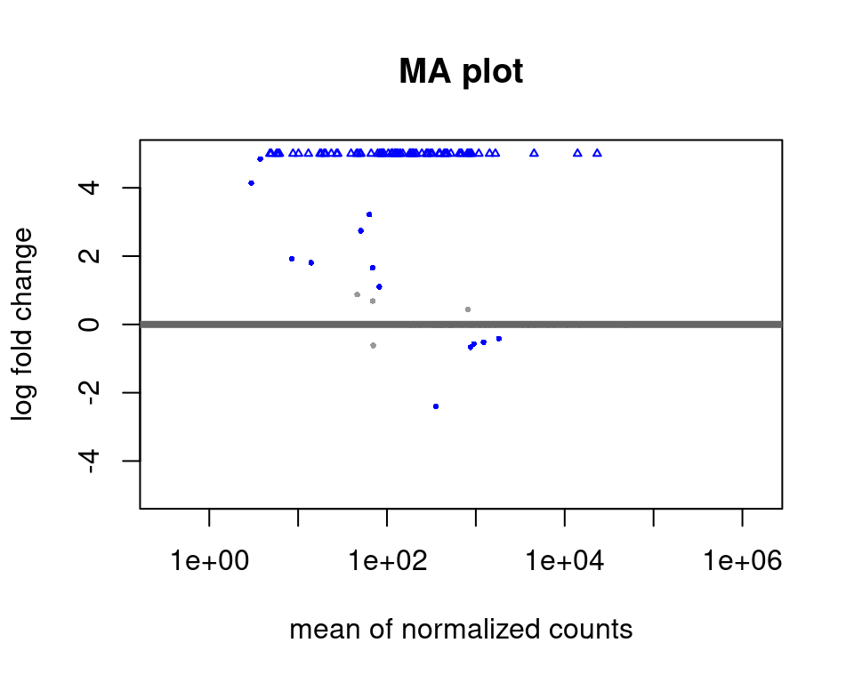

```r
DESeq2::plotMA(res, ylim=c(-5,5), main="MA plot")
```

### Volcano plot

The volcano plot arranges genes along two dimensions: the x-axis is the log fold change between the two groups, and the y-axis represents the adjusted P values between samples (on a negative log scale so smaller p-values appear higher up).

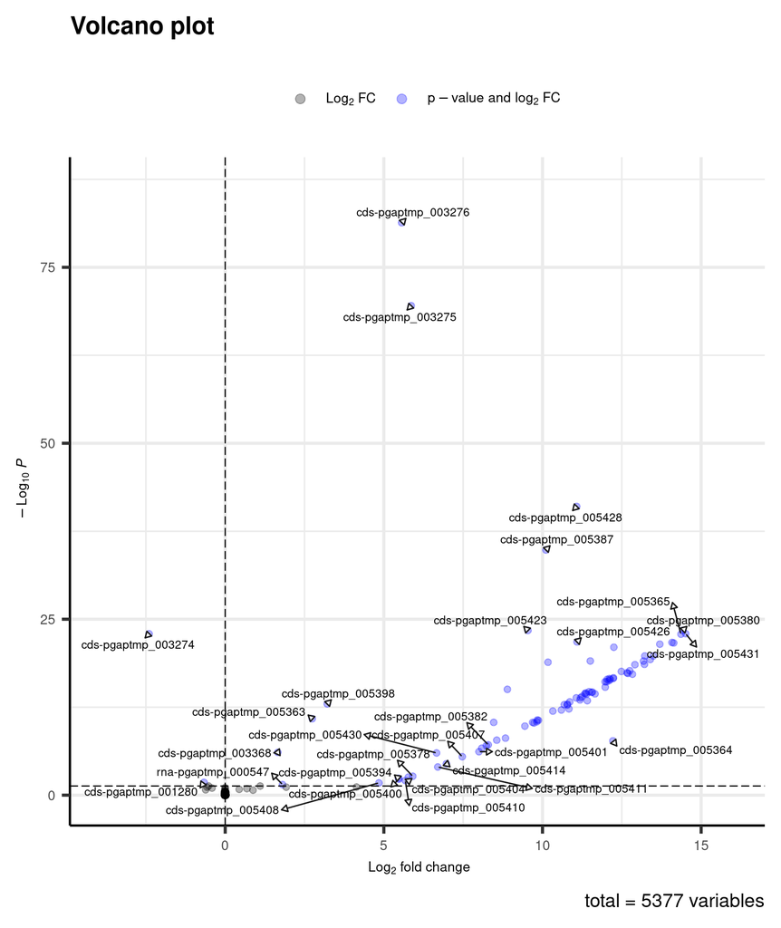

```r
EnhancedVolcano(res, lab = rownames(res), x = 'log2FoldChange', y = 'padj', pCutoff=0.05, FCcutoff=0, subtitleLabSize=0, axisLabSize=10, labSize=3, legendLabSize=10, legendIconSize=3, col=c('black', 'black', 'gold2', 'blue'), colAlpha = 0.3, drawConnectors = TRUE)
```